# Modern Data Mining: PCA

Bopei Nie

02/12/2023

# Overview

Principle Component Analysis is widely used in data exploration, dimension reduction, data visualization. The aim is to transform original data into uncorrelated linear combinations of the original data while keeping the information contained in the data. High dimensional data tends to show clusters in lower dimensional view.

Clustering Analysis is another form of EDA. Here we are hoping to group data points which are close to each other within the groups and far away between different groups. Clustering using PC’s can be effective. Clustering analysis can be very subjective in the way we need to summarize the properties within each group.

Both PCA and Clustering Analysis are so called unsupervised learning. There is no response variables involved in the process.

For supervised learning, we try to find out how does a set of predictors relate to some response variable of the interest. Multiple regression is still by far, one of the most popular methods. We use a linear models as a working model for its simplicity and interpretability. It is important that we use domain knowledge as much as we can to determine the form of the response as well as the function format of the factors on the other hand.

## 0.1 Objectives

- PCA
- SVD
- Clustering Analysis
- Linear Regression

## 0.2 Review materials

- Study Module 2: PCA
- Study Module 3: Clustering Analysis
- Study Module 4: Multiple regression

## 0.3 Data needed

- `NLSY79.csv`
- `brca_subtype.csv`
- `brca_x_patient.csv`

# 1 Case study 1: Self-seteem

Self-esteem generally describes a person’s overall sense of self-worthiness and personal value. It can play significant role in one’s motivation and success throughout the life. Factors that influence self-esteem can be inner thinking, health condition, age, life experiences etc. We will try to identify possible factors in our data that are related to the level of self-esteem.

In the well-cited National Longitudinal Study of Youth (NLSY79), it follows about 13,000 individuals and numerous individual-year information has been gathered through surveys. The survey data is open to public [here](https://www.nlsinfo.org/investigator/). Among many variables we assembled a subset of variables including personal demographic variables in different years, household environment in 79, ASVAB test Scores in 81 and Self-Esteem scores in 81 and 87 respectively.

The data is store in `NLSY79.csv`.

Here are the description of variables:

**Personal Demographic Variables**

- Gender: a factor with levels “female” and “male”
- Education05: years of education completed by 2005
- HeightFeet05, HeightInch05: height measurement. For example, a person of 5’10 will be recorded as HeightFeet05=5, HeightInch05=10.
- Weight05: weight in lbs.
- Income87, Income05: total annual income from wages and salary in 2005.
- Job87 (missing), Job05: job type in 1987 and 2005, including Protective Service Occupations, Food Preparation and Serving Related Occupations, Cleaning and Building Service Occupations, Entertainment Attendants and Related Workers, Funeral Related Occupations, Personal Care and Service Workers, Sales and Related Workers, Office and Administrative Support Workers, Farming, Fishing and Forestry Occupations, Construction Trade and Extraction Workers, Installation, Maintenance and Repairs Workers, Production and Operating Workers, Food Preparation Occupations, Setters, Operators and Tenders, Transportation and Material Moving Workers

**Household Environment**

- Imagazine: a variable taking on the value 1 if anyone in the respondent’s household regularly read magazines in 1979, otherwise 0
- Inewspaper: a variable taking on the value 1 if anyone in the respondent’s household regularly read newspapers in 1979, otherwise 0
- Ilibrary: a variable taking on the value 1 if anyone in the respondent’s household had a library card in 1979, otherwise 0
- MotherEd: mother’s years of education
- FatherEd: father’s years of education
- FamilyIncome78

**Variables Related to ASVAB test Scores in 1981**

| Test | Description |
| --- | --- |
| AFQT | percentile score on the AFQT intelligence test in 1981 |
| Coding | score on the Coding Speed test in 1981 |
| Auto | score on the Automotive and Shop test in 1981 |
| Mechanic | score on the Mechanic test in 1981 |
| Elec | score on the Electronics Information test in 1981 |
| Science | score on the General Science test in 1981 |
| Math | score on the Math test in 1981 |
| Arith | score on the Arithmetic Reasoning test in 1981 |
| Word | score on the Word Knowledge Test in 1981 |
| Parag | score on the Paragraph Comprehension test in 1981 |
| Numer | score on the Numerical Operations test in 1981 |

**Self-Esteem test 81 and 87**

We have two sets of self-esteem test, one in 1981 and the other in 1987. Each set has same 10 questions. They are labeled as `Esteem81` and `Esteem87` respectively followed by the question number. For example, `Esteem81_1` is Esteem question 1 in 81.

The following 10 questions are answered as 1: strongly agree, 2: agree, 3: disagree, 4: strongly disagree

- Esteem 1: “I am a person of worth”
- Esteem 2: “I have a number of good qualities”
- Esteem 3: “I am inclined to feel like a failure”
- Esteem 4: “I do things as well as others”
- Esteem 5: “I do not have much to be proud of”
- Esteem 6: “I take a positive attitude towards myself and others”
- Esteem 7: “I am satisfied with myself”
- Esteem 8: “I wish I could have more respect for myself”
- Esteem 9: “I feel useless at times”
- Esteem 10: “I think I am no good at all”

## 1.1 Data preparation

Load the data. Do a quick EDA to get familiar with the data set. Pay attention to the unit of each variable. Are there any missing values?

Regarding missing values, apart from the entirely missing job type in 1987 in the data set, there are some other missing values present. The data shows that the minimum value of `Income87` is -2. According to the original data set on the National Longitudinal Study of Youth website, the variable `Income87` indicates “Don’t Know” with a value of -2 and “Refusal” with a value of -1. Thus, some of the values of `Income87` are missing. In addition, there are some unusual values, such as the minimum value of `HeightFeet05`, which is -4, indicating an abnormal data point.

To ensure the reliability of the results, the rows containing missing or unusual values are deleted, as there isn’t a significant amount of missing data.

Besides, there are some variables with incorrect types. The `Subject` variable, which is assigned to each individual, should be a factor instead of a numerical value (integer). `Job05` is a character in the data set, but it should be transformed into a factor. Thus, these incorrect types are corrected.

Additionally, it is worth noticing that the unit of height is inch and feet, the unit of weight is lbs and the unit of income is dollars. Thus, in Question 6, we should first convert the unit before calculating BMI.

```r
temp <- read.csv('data/NLSY79.csv', header = T, stringsAsFactors = F)
summary(temp)
temp <-temp[temp$Income87 >= 0, ]
temp <-temp[temp$HeightFeet05 >= 0, ]
```

## 1.2 Self esteem evaluation

Let concentrate on Esteem scores evaluated in 87.

0. First do a quick summary over all the `Esteem` variables. Pay attention to missing values, any peculiar numbers etc. How do you fix problems discovered if there is any? Briefly describe what you have done for the data preparation.

In order to summarise all the `Esteem` variables, we select the columns containing “Esteem87” and store them in `data.esteem`. Then we apply`summary()` to `data.esteem` to look up the minimum, 1st quantile, median, mean, 3rd quantile and maximum of the variables that we are interested in.

The results shows that there is no missing values or peculiar data in the `Esteem` variables. The minimum and maximum of every esteem score evaluated in 1987 is 1 and 4, respectively.

```r
# select the columns containing "Esteem87", and use summary() to look into the data.
col_names <- colnames(temp)
esteem_cols <- col_names[grep("Esteem87", col_names)]
data.esteem <- temp[, esteem_cols]
summary(data.esteem)
```

```
##    Esteem87_1     Esteem87_2    Esteem87_3     Esteem87_4    Esteem87_5
##  Min.   :1.00   Min.   :1.0   Min.   :1.00   Min.   :1.0   Min.   :1.00
##  1st Qu.:1.00   1st Qu.:1.0   1st Qu.:3.00   1st Qu.:1.0   1st Qu.:3.00
##  Median :1.00   Median :1.0   Median :4.00   Median :1.0   Median :4.00
##  Mean   :1.38   Mean   :1.4   Mean   :3.58   Mean   :1.5   Mean   :3.53
##  3rd Qu.:2.00   3rd Qu.:2.0   3rd Qu.:4.00   3rd Qu.:2.0   3rd Qu.:4.00
##  Max.   :4.00   Max.   :4.0   Max.   :4.00   Max.   :4.0   Max.   :4.00
##    Esteem87_6     Esteem87_7     Esteem87_8    Esteem87_9    Esteem87_10
##  Min.   :1.00   Min.   :1.00   Min.   :1.0   Min.   :1.00   Min.   :1.00
##  1st Qu.:1.00   1st Qu.:1.00   1st Qu.:3.0   1st Qu.:3.00   1st Qu.:3.00
##  Median :2.00   Median :2.00   Median :3.0   Median :3.00   Median :3.00
##  Mean   :1.59   Mean   :1.72   Mean   :3.1   Mean   :3.06   Mean   :3.37
##  3rd Qu.:2.00   3rd Qu.:2.00   3rd Qu.:4.0   3rd Qu.:4.00   3rd Qu.:4.00
##  Max.   :4.00   Max.   :4.00   Max.   :4.0   Max.   :4.00   Max.   :4.00
```

1. Reverse Esteem 1, 2, 4, 6, and 7 so that a higher score corresponds to higher self-esteem.

```r
data.esteem[,  c(1, 2, 4, 6, 7)]  <- 5 - data.esteem[,  c(1, 2, 4, 6, 7)]
```

2. Write a brief summary with necessary plots about the 10 esteem measurements.

The graph shows the distribution of average score of the 10 esteem measurements. Most people score 2.7 to 4.0 on average of the ten questions, and the proportion of people receiving higher score are more than those receive lower scores. The highest average score is 4.0, which means this person obtain the maximum score in each measurement.

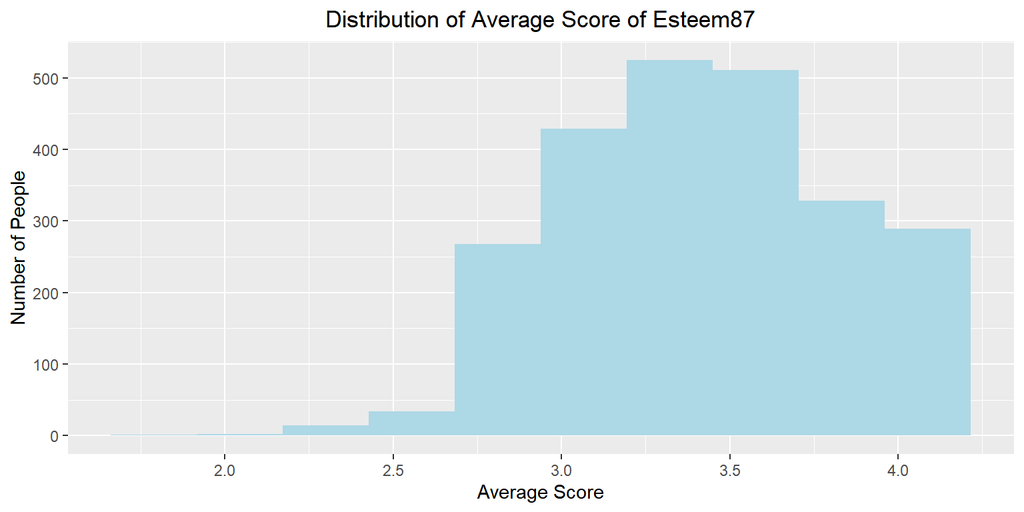

```r
data.esteem.2 <- data.esteem %>%  rowwise() %>% mutate(row_mean = mean(c(Esteem87_1,Esteem87_2,Esteem87_3,Esteem87_4,Esteem87_5,Esteem87_6,Esteem87_7,Esteem87_8,Esteem87_9,Esteem87_10)))

ggplot(data.esteem.2) +
geom_histogram(aes(x = row_mean), bins = 10, fill = "lightblue") +
scale_fill_brewer(type = "qual", palette = "Set1") +
labs( title = "Distribution of Average Score of Esteem87", x = "Average Score" , y = "Number of People") +
theme(plot.title = element_text(hjust = 0.5))
```

3. Do esteem scores all positively correlated? Report the pairwise correlation table and write a brief summary.

From the pairwise correlation table below, we can see that most esteem scores are clearly positively correlated although some are not strongly correlated.

The pairwise correlation table illustrates the correlation of 10 esteem scores in 1987. As the table reflects the symmetric data, we can focus on the plots on bottom left.

It is worth noticing that all those spots represent the score of the ten esteem questions between one to four.

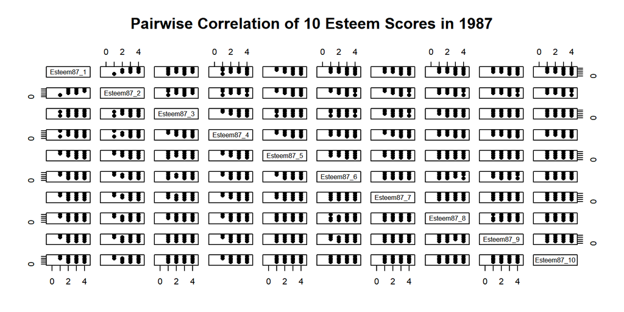

```r
pairs(data.esteem, xlim=c(-0.5, 4.5), ylim=c(-0.5, 4.5), pch=16, main = "Pairwise Correlation of 10 Esteem Scores in 1987")
```

Furthermore, we select some of the pairwise correlation plots and zoom in to see in detail. The circles indicates the number of score pairs. The more frequently a pair of data points appears in the dataset, the larger the circles, and the more circles there are. From those graphs, we can see that most of the pairs are positively correlated.

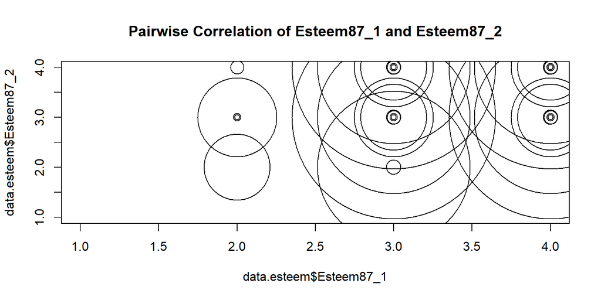

```r
# Calculate the frequency of each data point
point_counts <- table(data.esteem$Esteem87_1, data.esteem$Esteem87_2)
# Create a variable to store the cex values based on the frequency of each data point
cex_values <- sqrt(point_counts)
# Plot the data, using cex values to control the size of the points
p1 <- plot(data.esteem$Esteem87_1, data.esteem$Esteem87_2, cex = cex_values, main = "Pairwise Correlation of Esteem87_1 and Esteem87_2")
```

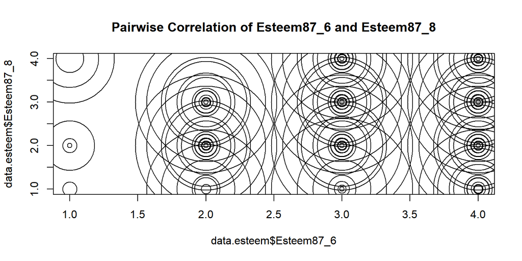

```r
point_counts <- table(data.esteem$Esteem87_6, data.esteem$Esteem87_8)
cex_values <- sqrt(point_counts)
p2 <- plot(data.esteem$Esteem87_6, data.esteem$Esteem87_8, cex = cex_values, main = "Pairwise Correlation of Esteem87_6 and Esteem87_8")
```

4. PCA on 10 esteem measurements. (centered but no scaling)
   1. Report the PC1 and PC2 loadings. Are they unit vectors? Are they orthogonal?

PC1 and PC2 loadings are shown in the table.

The first two principal components (PC1 and PC2) are linear combinations of the original variables in the data. The loadings of PC1 and PC2 represent the weight given to each original variable in the calculation of the first two PCs.

The loadings of PC1 and PC2 are unit vectors, and they represent the relative importance of the variables in the calculation of the PCs.

PC1 and PC2 are orthogonal, which means that they are perpendicular to each other. Orthogonality is a property of principal component analysis (PCA) that ensures that the first PC captures the maximum amount of variance in the data, the second PC captures the maximum amount of variance in the data that is orthogonal to the first PC, and so on. This property helps to simplify the interpretation of the PCs, as each PC captures a unique aspect of the data that is not captured by any of the other PCs.

```r
pc_10 <- prcomp(data.esteem, scale=FALSE) # by default, center=True but scale=FALSE!!!

pc_10.loading <- pc_10$rotation
knitr::kable(pc_10.loading[,1:2])
```

|  | PC1 | PC2 |
| --- | --- | --- |
| Esteem87_1 | 0.234 | -0.376 |
| Esteem87_2 | 0.244 | -0.370 |
| Esteem87_3 | 0.278 | -0.152 |
| Esteem87_4 | 0.260 | -0.323 |
| Esteem87_5 | 0.312 | -0.133 |
| Esteem87_6 | 0.312 | -0.207 |
| Esteem87_7 | 0.299 | -0.159 |
| Esteem87_8 | 0.394 | 0.331 |
| Esteem87_9 | 0.400 | 0.575 |
| Esteem87_10 | 0.376 | 0.260 |

```
b) Are there good interpretations for PC1 and PC2? (If loadings are all negative, take the positive loadings for the ease of interpretation)
```

Each loadings give us a set of ten numbers which determines the direction of each line. Loadings are unique up to sign, so we can change all of the signs and maintain the information stored in them.

Regarding PC1, it is worth noticing that the ten loadings are approximately the same around 0.3, and thus PC1 is proportional to the total of the ten scores. Also, we should not neglect the fact that loadings of Esteem87_1, 2, 3 and Esteem87_4, which are around 0.25, are slightly smaller than the counterpart of the last six scores. The difference in weight indicates that the first four esteem score contributes slightly less than the last six scores in constructing PC1.

In general, PC1 is approximately the weighted sum of all ten scores. Besides, from the value of loadings of PC1, we can tell that a higher PC1 indicates a higher weighted total score.

As for PC2, notice that the value of PC2 is difference between the sum of the scores of Esteem87_8, Esteem87_9 and Esteem87_10 and the sum of the first 7 scores. So, PC2 is approximately proportional to the difference between the sum of last three scores and that of the first seven scores of 1987. Furthermore, if the total scores are comparable, higher PC2 implies strong self-esteem in the aspects represented by the last three questions relatively, while lower PC2 implies relatively higher level of self-esteem in the aspects represented by the first seven questions.

```
c) How is the PC1 score obtained for each subject? Write down the formula.
```

According to the definition, we derive the formula by taking the linear combination of loadings and variables. To be more precise, we multiply the vector of loadings to the vector of variables.

Regarding PC1, take the linear combination according to the loadings, we get:

PC1 = 0.234 × Esteem87_1 + 0.244 × Esteem87_2 + 0.278 × Esteem87_3 + 0.260 × Esteem87_4 + 0.312 × Esteem87_5 + 0.312 × Esteem87_6 + 0.299 × Esteem87_7 + 0.394 × Esteem87_8 + 0.400 × Esteem87_9 + 0.376 × Esteem87_10

Then, we apply the same method to compute the value of PC2:

PC2 = (-0.376 × Esteem87_1) + (-0.370 × Esteem87_2) + (-0.152 × Esteem87_3) + (-0.323 × Esteem87_4) + (-0.133 × Esteem87_5) + (-0.207 × Esteem87_6) + (-0.159 × Esteem87_7) + 0.331 × Esteem87_8 + 0.575 × Esteem87_9 + 0.260 × Esteem87_10

= -(0.376 × Esteem87_1 + 0.370 × Esteem87_2 + 0.152 × Esteem87_3 + 0.323 × Esteem87_4 + 0.133 × Esteem87_5 + 0.207 × Esteem87_6 + 0.159 × Esteem87_7) + (0.331 × Esteem87_8 + 0.575 × Esteem87_9 + 0.260 × Esteem87_10)

Besides, we can compute the PC1 and PC2 and plot them using the following code.

```r
pc_scores <- cbind(scale(data.esteem, scale = FALSE), pc_10$x)
arrange(as.data.frame(pc_scores)) %>%
head()
```

```
##   Esteem87_1 Esteem87_2 Esteem87_3 Esteem87_4 Esteem87_5 Esteem87_6 Esteem87_7
## 1     -0.621      0.401      0.417      0.504     -1.534     -0.407     -0.282
## 2      0.379      0.401      0.417      0.504      0.466      0.593     -0.282
## 3     -0.621     -0.599      0.417     -0.496      0.466     -0.407     -0.282
## 4      0.379      0.401     -0.583      0.504      0.466     -0.407      0.718
## 5      0.379      0.401      0.417      0.504      0.466      0.593      0.718
## 6      0.379      0.401      0.417      0.504      0.466      0.593     -0.282
##   Esteem87_8 Esteem87_9 Esteem87_10    PC1    PC2      PC3    PC4     PC5
## 1    -0.0995    -0.0646       0.631 -0.318  0.287  0.27199  0.475  0.6088
## 2    -0.0995    -1.0646       0.631  0.453 -1.138 -0.04594 -0.588 -0.2369
## 3     0.9005    -0.0646       0.631  0.196  1.044 -0.52221 -1.018 -0.5108
## 4    -1.0995    -1.0646      -1.369 -0.985 -1.790  0.00627  0.299 -0.1814
## 5     0.9005     0.9354       0.631  1.945  0.185 -0.12272  0.221  0.0309
## 6     0.9005     0.9354       0.631  1.646  0.344  0.01440 -0.271  0.5446
##       PC6     PC7     PC8     PC9    PC10
## 1 -1.2512  0.2634  0.8006 -0.5981 -0.7047
## 2 -0.8949 -0.2353  0.0180  0.4004 -0.0393
## 3 -0.3319  0.0360  0.1077 -0.1332 -0.0303
## 4  0.9288 -0.4360 -0.5162 -0.6290  0.0289
## 5  0.1107 -0.0112  0.0238 -0.0753  0.0074
## 6 -0.0918 -0.2141  0.1542  0.4343 -0.0292
```

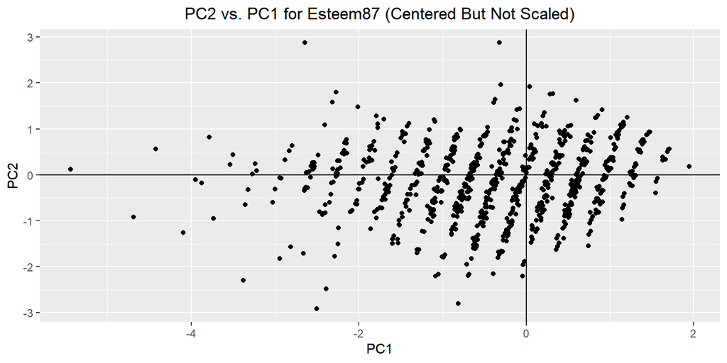

```
d) Are PC1 scores and PC2 scores in the data uncorrelated?
```

```r
as.data.frame(pc_10$x) %>%
ggplot(aes(x=PC1, y=PC2)) +
geom_point()+
geom_vline(xintercept = 0) +
geom_hline(yintercept = 0) +
ggtitle("PC2 vs. PC1 for Esteem87 (Centered But Not Scaled)") +
theme(plot.title = element_text(hjust = 0.5))
```

Theoretically, the first two principal components (PC1 and PC2) are orthogonal to each other, meaning that they are uncorrelated. This means that the correlation between the PC1 scores and PC2 scores should be close to zero.

However, this does not always guarantee that the PC1 scores and PC2 scores will be perfectly uncorrelated, as there may be some slight rounding errors or numerical instability in the PCA computation. In practice, it depends on the specific data and the way the principal component analysis (PCA) was performed. It is common to use a threshold to define the uncorrelatedness of the two components, such as a correlation coefficient below a certain value (e.g., 0.01 or 0.05). If the correlation between PC1 and PC2 scores is below this threshold, they can be considered uncorrelated.

```r
cor(pc_scores[, "PC1"], pc_scores[, "PC2"])
```

```
## [1] -1.6e-15
```

In this specific data set, we can calculate the correlation of PC1 and PC2 to check if they are correlated. The result should that the correlation of PC1 and PC2 is -1.6e-15, which is a rather small number (in absolute value). Therefore, we can conclude that PC1 and PC2 are uncorrelated in this data set.

```
e) Plot PVE (Proportion of Variance Explained) and summarize the plot.
```

```r
summary(pc_10)$importance
```

```
##                          PC1   PC2   PC3   PC4   PC5    PC6    PC7    PC8
## Standard deviation     1.296 0.676 0.569 0.519 0.461 0.4321 0.3734 0.3660
## Proportion of Variance 0.467 0.127 0.090 0.075 0.059 0.0519 0.0387 0.0372
## Cumulative Proportion  0.467 0.594 0.684 0.759 0.818 0.8697 0.9084 0.9456
##                           PC9   PC10
## Standard deviation     0.3490 0.2718
## Proportion of Variance 0.0338 0.0205
## Cumulative Proportion  0.9795 1.0000
```

The summary reports standard deviations, PVE (PVE = Var(PC) / Total Variances) and cumulative proportions and .

From the second row of the table, we can clearly see the proportion of variance of PCs. The leading principal component (PC1) explains almost half of the total variance (46.7%) and the PC2 explains 12.7% of the total variance. Besides, it is worth noticing the relationship: Var(PC1)>Var(PC2)>…>Var(PC10) from data, which is in line with the theoretical expectations.

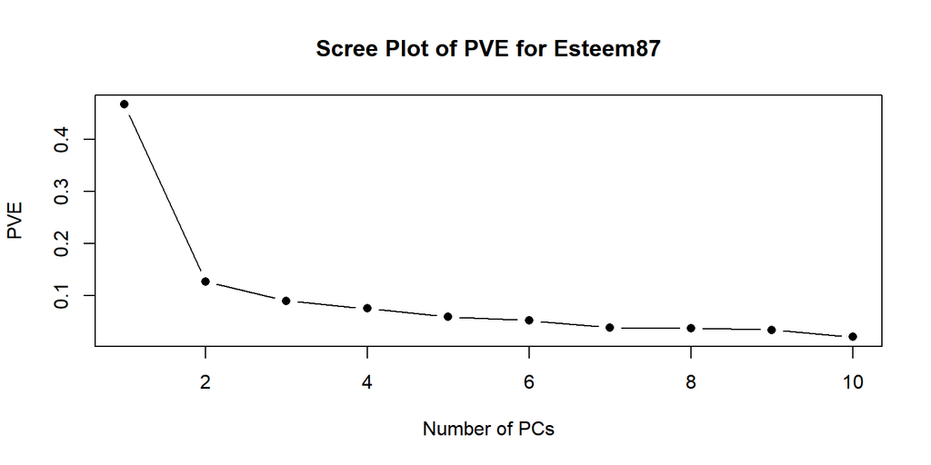

```
f) Also plot CPVE (Cumulative Proportion of Variance Explained). What proportion of the variance in the data is explained by the first two principal components?
```

```r
plot(summary(pc_10)$importance[2, ], # PVE
     ylab="PVE",
     xlab="Number of PCs",
     pch = 16,
     main="Scree Plot of PVE for Esteem87",
     type="b")
```

From the data from Cumulative Proportion of Variance Explained, we can see that 59.4% of the variance in the data is explained by the first two principal components.

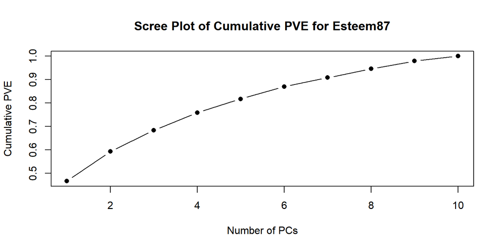

```
g) PC’s provide us with a low dimensional view of the self-esteem scores. Use a biplot with the first two PC's to display the data.  Give an interpretation of PC1 and PC2 from the plot. (try `ggbiplot` if you could, much prettier!)
```

```r
plot(summary(pc_10)$importance[3, ], pch=16,
ylab="Cumulative PVE",
xlab="Number of PCs",
type="b",
main="Scree Plot of Cumulative PVE for Esteem87")
```

[figure not shown]

```r
p <- biplot(pc_10, choices=c(1,2),
xlim=c(-0.09,0.05),
ylim=c(-0.09,0.06),
main="Biplot of PC1 and PC2")
abline(v=0, h=0)
```

The biplot indicates:

• PC1 loadings are similar in magnitudes and with same signs. • PC2 captures difference between total of Esteem87_1, 2, …, 7 and total of the last three scores(Esteem87_8, 9 and 10). • There are three groups of scores that are highly correlated.

- Esteem87_1, 2 and 4 are highly correlated.
- Esteem87_3, 5, 6 and 7 are highly correlated.
- Esteem87_8, 9 and 10 are highly correlated.

This result provides an insight that inside each group, the scores may represents the similar aspect of self-esteem.

5. Apply k-means to cluster subjects on the original esteem scores
   1. Find a reasonable number of clusters using within sum of squared with elbow rules.

From the plot: “Optimal number of clusters”, we can see that as the number of clusters k increases, total within sum square decreases. Furthermore, a sharp drop of total within sum square occur when the number of k equals to two. Also, when k is larger than three, the slope doesn’t change much when k increases. According to the elbow rule, it is appropriate to choose the number of k “at the elbow”. That is to say, it is reasonable to set k equals to three in order to get the better clustering results.

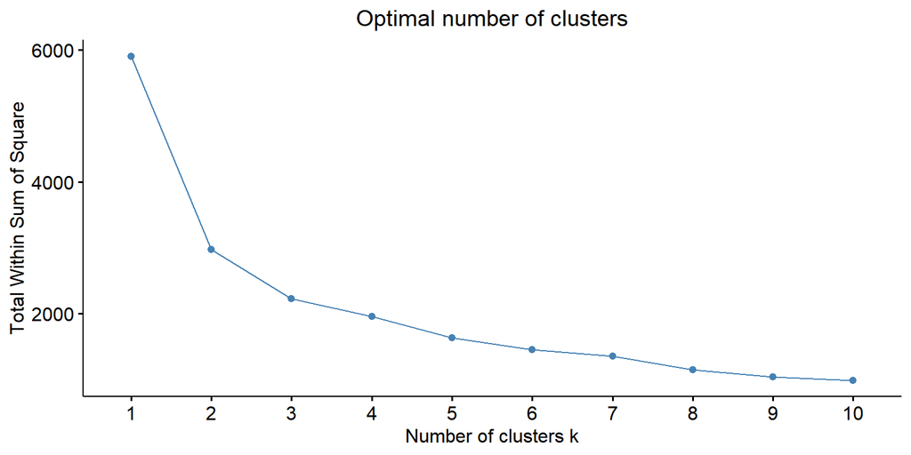

```
b) Can you summarize common features within each cluster?
```

```r
set.seed(0)
pc_clus <- as.data.frame(pc_10$x)

fviz_nbclust(pc_clus[,1:3], kmeans, method = "wss")+
  theme(plot.title = element_text(hjust = 0.5))
```

When using K-Means, the algorithm aims to divide the data into K clusters (here K = 3) such that the data points within each cluster are as similar as possible, based on a similarity metric, such as Euclidean distance, while data points in different clusters are as dissimilar as possible.

```r
pc_kmeans <- kmeans(pc_clus, centers = 3 )
str(pc_kmeans)
```

```
## List of 9
##  $ cluster     : Named int [1:2401] 1 1 3 1 3 3 3 2 3 3 ...
##   ..- attr(*, "names")= chr [1:2401] "1" "2" "3" "4" ...
##  $ centers     : num [1:3, 1:10] 0.0709 -1.3661 1.4783 -0.5745 0.293 ...
##   ..- attr(*, "dimnames")=List of 2
##   .. ..$ : chr [1:3] "1" "2" "3"
##   .. ..$ : chr [1:10] "PC1" "PC2" "PC3" "PC4" ...
##  $ totss       : num 8636
##  $ withinss    : num [1:3] 2125 1784 1038
##  $ tot.withinss: num 4948
##  $ betweenss   : num 3689
##  $ size        : int [1:3] 792 856 753
##  $ iter        : int 3
##  $ ifault      : int 0
##  - attr(*, "class")= chr "kmeans"
```

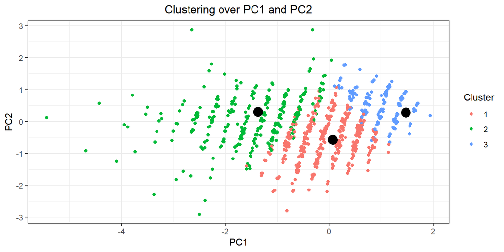

```r
p1 <- data.table(x = pc_10$x[,1],
y = pc_10$x[,2],
col = as.factor(pc_kmeans$cluster),
pc1 = pc_kmeans$centers[,1],
pc2 = pc_kmeans$centers[,2]) %>%
ggplot() +
geom_point(aes(x = x, y = y, col = col)) +
geom_point(aes(x = pc1, y = pc2), size = 5) +
theme_bw() +
labs(color = "Cluster") +
xlab("PC1") +
ylab("PC2")+
ggtitle("Clustering over PC1 and PC2")+
  theme(plot.title = element_text(hjust = 0.5))
p1
```

From the analysis of this graph, it is evident that there are three distinct clusters with well-defined boundaries.

The first cluster, depicted in red, is situated in the mid-bottom section of the graph and encompasses individuals whose total esteem score is approximately equal to the sample mean. The average of Esteem87_8, 9 and 10 is lower than the mean of Esteem87_1, 2, … , 7.

The green dots make up the second cluster and correspond to individuals whose total esteem score is below the average. The cluster center is positioned above the horizontal line PC2 = 0, indicating that these individuals generally score higher on the mean of the last three esteem scores compared to the first seven. It is also worth noting that there are some individuals within the cluster whose mean score on the last three esteem scores is lower than the mean score on the first seven.

The third cluster comprises individuals with the highest levels of self-esteem, as evidenced by the largest average score of PC1. This cluster also generally demonstrates a higher average score on the last three esteem scores compared to the first seven.

```
c) Can you visualize the clusters with somewhat clear boundaries? You may try different pairs of variables and different PC pairs of the esteem scores.
```

In the following graphs, we plot the clusters over PCs pairwisely. It shows that the cluster over PC1 and PC2 has the best performance and the clearest boundaries.

Besides, since the variables Esteem87_1 to Esteem887_10 can only take values: 1, 2, 3 and 4, it’s not suitable to put those variables directly to operate clustering.

Thus, we choose the best clustering with the clearest boundaries: the clustering over PC1 and PC2.

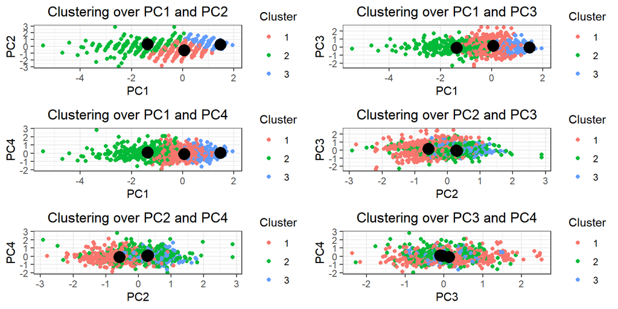

```r
p1 <- data.table(x = pc_10$x[,1],
y = pc_10$x[,2],
col = as.factor(pc_kmeans$cluster),
pc1 = pc_kmeans$centers[,1],
pc2 = pc_kmeans$centers[,2])%>%
ggplot() +
geom_point(aes(x = x, y = y, col = col)) +
geom_point(aes(x = pc1, y = pc2), size = 5) +

theme_bw() +
labs(color = "Cluster") +
xlab("PC1") +
ylab("PC2")+
ggtitle("Clustering over PC1 and PC2")+
  theme(plot.title = element_text(hjust = 0.5))


p2 <- data.table(x = pc_10$x[,1],
y = pc_10$x[,3],
col = as.factor(pc_kmeans$cluster),
pc1 = pc_kmeans$centers[,1],
pc3= pc_kmeans$centers[,3])%>%
ggplot() +
geom_point(aes(x = x, y = y, col = col)) +
geom_point(aes(x = pc1, y = pc3), size = 5) +
theme_bw() +
labs(color = "Cluster") +
xlab("PC1") +
ylab("PC3")+
ggtitle("Clustering over PC1 and PC3")+
  theme(plot.title = element_text(hjust = 0.5))

p3 <- data.table(x = pc_10$x[,1],
y = pc_10$x[,4],
col = as.factor(pc_kmeans$cluster),
pc1 = pc_kmeans$centers[,1],
pc4= pc_kmeans$centers[,4])%>%
ggplot() +
geom_point(aes(x = x, y = y, col = col)) +
geom_point(aes(x = pc1, y = pc4), size = 5) +
theme_bw() +
labs(color = "Cluster") +
xlab("PC1") +
ylab("PC4")+
ggtitle("Clustering over PC1 and PC4")+
  theme(plot.title = element_text(hjust = 0.5))

p4 <- data.table(x = pc_10$x[,2],
y = pc_10$x[,3],
col = as.factor(pc_kmeans$cluster),
pc2 = pc_kmeans$centers[,2],
pc3= pc_kmeans$centers[,3])%>%
ggplot() +
geom_point(aes(x = x, y = y, col = col)) +
geom_point(aes(x = pc2, y = pc3), size = 5) +
theme_bw() +
labs(color = "Cluster") +
xlab("PC2") +
ylab("PC3")+
ggtitle("Clustering over PC2 and PC3")+
  theme(plot.title = element_text(hjust = 0.5))

p5 <- data.table(x = pc_10$x[,2],
y = pc_10$x[,4],
col = as.factor(pc_kmeans$cluster),
pc2 = pc_kmeans$centers[,2],
pc4= pc_kmeans$centers[,4])%>%
ggplot() +
geom_point(aes(x = x, y = y, col = col)) +
geom_point(aes(x = pc2, y = pc4), size = 5) +
theme_bw() +
labs(color = "Cluster") +
xlab("PC2") +
ylab("PC4")+
ggtitle("Clustering over PC2 and PC4")+
  theme(plot.title = element_text(hjust = 0.5))

p6 <- data.table(x = pc_10$x[,3],
y = pc_10$x[,4],
col = as.factor(pc_kmeans$cluster),
pc3 = pc_kmeans$centers[,3],
pc4= pc_kmeans$centers[,4])%>%
ggplot() +
geom_point(aes(x = x, y = y, col = col)) +
geom_point(aes(x = pc3, y = pc4), size = 5) +
theme_bw() +
labs(color = "Cluster") +
xlab("PC3") +
ylab("PC4")+
ggtitle("Clustering over PC3 and PC4")+
  theme(plot.title = element_text(hjust = 0.5))

grid.arrange(p1,p2, p3, p4, p5,p6, nrow = 3, ncol = 2)
```

6. We now try to find out what factors are related to self-esteem? PC1 of all the Esteem scores is a good variable to summarize one’s esteem scores. We take PC1 as our response variable.
   1. Prepare possible factors/variables:
   - EDA the data set first.

```r
# already read in temp
dim(temp)
head(temp)
```

[output not shown]

Because the units of height are inch and feet and the unit of weight is lbs in the original data set, we should first convert the units into meter and kilogram before calculating BMI. (1 feet = 0.3048m, 1inch = 0.0254m). Then, we calculate BMI and take logs to Income87.

```r
feet_to_meters <- function(feet, inches) {
  meters <- 0.3048 * feet + 0.0254 * inches
  return(meters)
}
h = feet_to_meters(temp$HeightFeet05, temp$HeightInch05)

lbs_to_kg <- function(lbs) {
  kg <- lbs * 0.45359237
  return(kg)
}
w = lbs_to_kg(temp$Weight05)

BMI <- w/(h*h)
lg_inc87 <- log(temp$Income87)
```

```
  - Household environment: Imagazine, Inewspaper, Ilibrary, MotherEd, FatherEd, FamilyIncome78. Do set indicators `Imagazine`, `Inewspaper` and `Ilibrary` as factors.
```

```r
magazine <- as.factor(temp$Imagazine)
newspaper <- as.factor(temp$Inewspaper)
library <- as.factor(temp$Ilibrary)
```

```
  - You may use PC1 of ASVAB as level of intelligence
```

Apply PCA method to the ten scores in ASVAB to get the level of intelligence. Since PC1 explains a significantly large amount of variance, and all loadings of PC1 are of similar magnitude and same sign, we use PC1 to represent the intelligence.

```r
# get PC1 of ASVAB as level of intelligence
pca.asvab <- prcomp(temp[, c(16:25)], scale=T) # all the tests
intell <- pca.asvab$x[,1]
```

Finally, construct the dataframe of all independent variables interested and response variable.

```r
data.reg <- data.frame(gender = temp$Gender, educ = temp$Education05, lg_inc87 = lg_inc87, BMI = BMI, magazine=magazine,newspaper=newspaper,library=library, momed=temp$MotherEd, daded=temp$FatherEd, inc_78 = temp$FamilyIncome78, intell = intell, PC1=pc_scores[,"PC1"])

head(data.reg)
```

```
b)   Run a few regression models between PC1 of all the esteem scores and suitable variables listed in a). Find a final best model with your own criterion.

  - How did you land this model? Run a model diagnosis to see if the linear model assumptions are reasonably met.

  - Write a summary of your findings. In particular, explain what and how the variables in the model affect one's self-esteem.
```

```r
fit1 <- lm(formula=PC1 ~ educ+ BMI+ magazine+ newspaper+ library+ momed+ daded+ inc_78+ intell, data = data.reg)
summary(fit1)
```

```
##
## Call:
## lm(formula = PC1 ~ educ + BMI + magazine + newspaper + library +
##     momed + daded + inc_78 + intell, data = data.reg)
##
## Residuals:
##    Min     1Q Median     3Q    Max
## -5.308 -0.944 -0.056  1.010  2.994
##
## Coefficients:
##              Estimate Std. Error t value Pr(>|t|)
## (Intercept) -1.26e+00   2.42e-01   -5.20  2.2e-07 ***
## educ         6.36e-02   1.25e-02    5.09  3.9e-07 ***
## BMI         -3.07e-03   4.35e-03   -0.71    0.480
## magazine1    2.63e-02   6.23e-02    0.42    0.673
## newspaper1   1.39e-01   8.04e-02    1.73    0.084 .
## library1     7.83e-02   6.34e-02    1.24    0.217
## momed        1.52e-02   1.30e-02    1.17    0.240
## daded        1.53e-03   9.63e-03    0.16    0.874
## inc_78       2.91e-06   1.99e-06    1.46    0.145
## intell       8.72e-02   1.31e-02    6.65  3.6e-11 ***
## ---
## Signif. codes:  0 '***' 0.001 '**' 0.01 '*' 0.05 '.' 0.1 ' ' 1
##
## Residual standard error: 1.23 on 2391 degrees of freedom
## Multiple R-squared:  0.0962, Adjusted R-squared:  0.0928
## F-statistic: 28.3 on 9 and 2391 DF,  p-value: <2e-16
```

Then, we move out mother education and father education. The regression result is as follow.

```r
fit2 <- lm(formula=PC1 ~ educ+ BMI+ magazine+ newspaper+ inc_78+ intell, data = data.reg)
summary(fit2)
```

```
##
## Call:
## lm(formula = PC1 ~ educ + BMI + magazine + newspaper + inc_78 +
##     intell, data = data.reg)
##
## Residuals:
##    Min     1Q Median     3Q    Max
## -5.303 -0.953 -0.061  1.005  3.049
##
## Coefficients:
##              Estimate Std. Error t value Pr(>|t|)
## (Intercept) -1.12e+00   2.26e-01   -4.95  8.0e-07 ***
## educ         6.87e-02   1.22e-02    5.66  1.7e-08 ***
## BMI         -3.43e-03   4.34e-03   -0.79    0.430
## magazine1    4.34e-02   6.15e-02    0.71    0.480
## newspaper1   1.74e-01   7.84e-02    2.22    0.027 *
## inc_78       3.48e-06   1.95e-06    1.78    0.075 .
## intell       9.16e-02   1.28e-02    7.18  9.1e-13 ***
## ---
## Signif. codes:  0 '***' 0.001 '**' 0.01 '*' 0.05 '.' 0.1 ' ' 1
##
## Residual standard error: 1.23 on 2394 degrees of freedom
## Multiple R-squared:  0.0947, Adjusted R-squared:  0.0924
## F-statistic: 41.7 on 6 and 2394 DF,  p-value: <2e-16
```

```r
fit3 <- lm(formula=PC1 ~ educ+ newspaper+ inc_78+ intell, data = data.reg)
summary(fit3)
```

```
##
## Call:
## lm(formula = PC1 ~ educ + newspaper + inc_78 + intell, data = data.reg)
##
## Residuals:
##    Min     1Q Median     3Q    Max
## -5.288 -0.962 -0.057  1.012  3.033
##
## Coefficients:
##              Estimate Std. Error t value Pr(>|t|)
## (Intercept) -1.22e+00   1.78e-01   -6.82  1.2e-11 ***
## educ         7.03e-02   1.21e-02    5.83  6.2e-09 ***
## newspaper1   1.83e-01   7.73e-02    2.37    0.018 *
## inc_78       3.70e-06   1.94e-06    1.91    0.057 .
## intell       9.33e-02   1.26e-02    7.43  1.5e-13 ***
## ---
## Signif. codes:  0 '***' 0.001 '**' 0.01 '*' 0.05 '.' 0.1 ' ' 1
##
## Residual standard error: 1.23 on 2396 degrees of freedom
## Multiple R-squared:  0.0942, Adjusted R-squared:  0.0927
## F-statistic: 62.3 on 4 and 2396 DF,  p-value: <2e-16
```

# 2 Case study 2: Breast cancer sub-type

[The Cancer Genome Atlas (TCGA)](https://www.cancer.gov/about-nci/organization/ccg/research/structural-genomics/tcga), a landmark cancer genomics program by National Cancer Institute (NCI), molecularly characterized over 20,000 primary cancer and matched normal samples spanning 33 cancer types. The genome data is open to public from the [Genomic Data Commons Data Portal (GDC)](https://portal.gdc.cancer.gov/).

In this study, we focus on 4 sub-types of breast cancer (BRCA): basal-like (basal), Luminal A-like (lumA), Luminal B-like (lumB), HER2-enriched. The sub-type is based on PAM50, a clinical-grade luminal-basal classifier.

- Luminal A cancers are low-grade, tend to grow slowly and have the best prognosis.
- Luminal B cancers generally grow slightly faster than luminal A cancers and their prognosis is slightly worse.
- HER2-enriched cancers tend to grow faster than luminal cancers and can have a worse prognosis, but they are often successfully treated with targeted therapies aimed at the HER2 protein.
- Basal-like breast cancers or triple negative breast cancers do not have the three receptors that the other sub-types have so have fewer treatment options.

We will try to use mRNA expression data alone without the labels to classify 4 sub-types. Classification without labels or prediction without outcomes is called unsupervised learning. We will use K-means and spectrum clustering to cluster the mRNA data and see whether the sub-type can be separated through mRNA data.

We first read the data using `data.table::fread()` which is a faster way to read in big data than `read.csv()`.

```r
brca <- fread("data/brca_subtype.csv")

# get the sub-type information
brca_subtype <- brca$BRCA_Subtype_PAM50
```

1. Summary and transformation
   1. How many patients are there in each sub-type?

```r
table(brca_subtype)
```

```
## brca_subtype
## Basal  Her2  LumA  LumB
##   208    91   628   233
```

There are 628 LumA, 233 LumB, 91 Her2, and 208 Basal.

```
b) Randomly pick 5 genes and plot the histogram by each sub-type.
```

```r
set.seed(5)
selected_columns <- sample(colnames(brca[,-1]), 5)
selected_columns
```

```
## [1] "SGPP1"     "NARFL"     "C10orf120" "ABI2"      "MAP1LC3B"
```

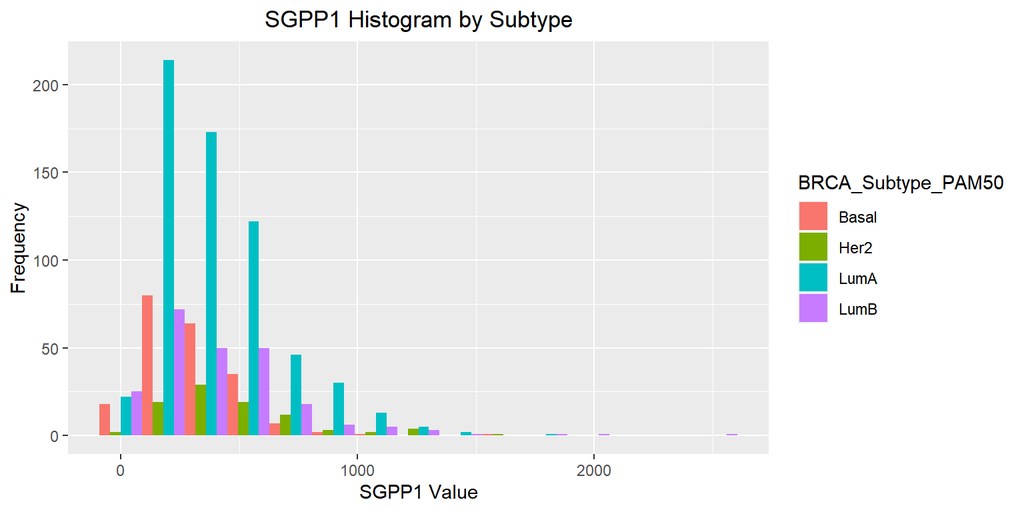

```r
randgene1<-brca[, c("BRCA_Subtype_PAM50", "SGPP1")]

ggplot(randgene1, aes(x = SGPP1, fill = BRCA_Subtype_PAM50)) +
  geom_histogram(bins = 15, position = "dodge") +
  labs(title = "SGPP1 Histogram by Subtype", x = "SGPP1 Value", y = "Frequency") +
theme(plot.title = element_text(hjust = 0.5))
```

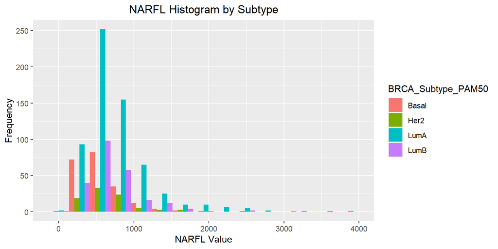

```r
randgene2<-brca[, c("BRCA_Subtype_PAM50", "NARFL")]

ggplot(randgene2, aes(x = NARFL, fill = BRCA_Subtype_PAM50)) +
  geom_histogram(bins = 15, position = "dodge") +
  labs(title = "NARFL Histogram by Subtype", x = "NARFL Value", y = "Frequency") +
theme(plot.title = element_text(hjust = 0.5))
```

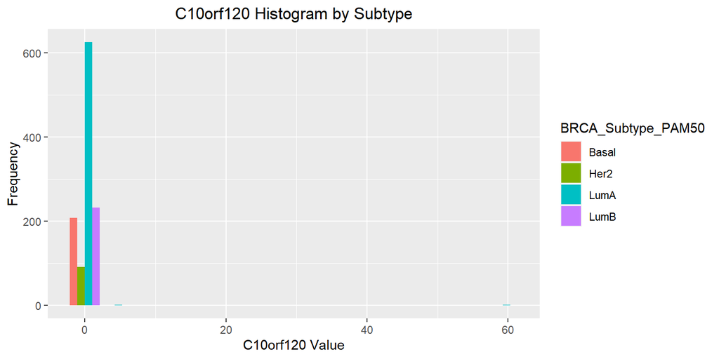

```r
randgene3<-brca[, c("BRCA_Subtype_PAM50", "C10orf120")]

ggplot(randgene3, aes(x = C10orf120, fill = BRCA_Subtype_PAM50)) +
  geom_histogram(bins = 15, position = "dodge") +
  labs(title = "C10orf120 Histogram by Subtype", x = "C10orf120 Value", y = "Frequency") +
theme(plot.title = element_text(hjust = 0.5))
```

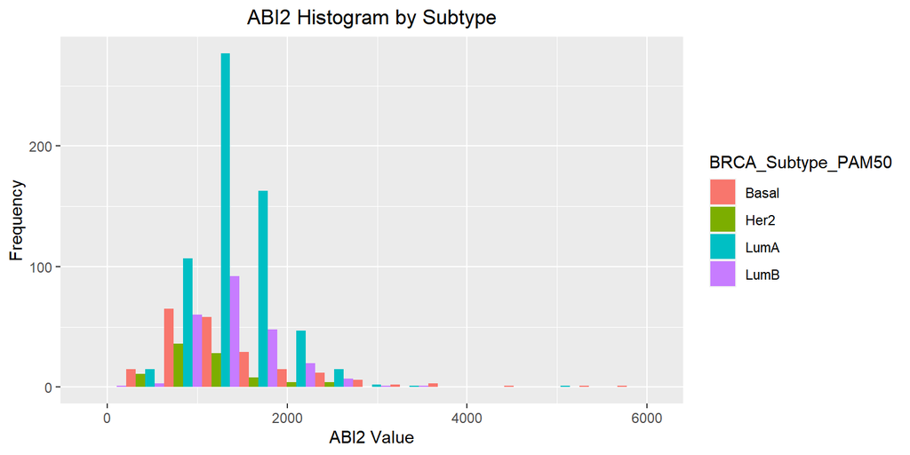

```r
randgene4<-brca[, c("BRCA_Subtype_PAM50", "ABI2")]

ggplot(randgene4, aes(x = ABI2, fill = BRCA_Subtype_PAM50)) +
  geom_histogram(bins = 15, position = "dodge") +
  labs(title = "ABI2 Histogram by Subtype", x = "ABI2 Value", y = "Frequency") +
theme(plot.title = element_text(hjust = 0.5))
```

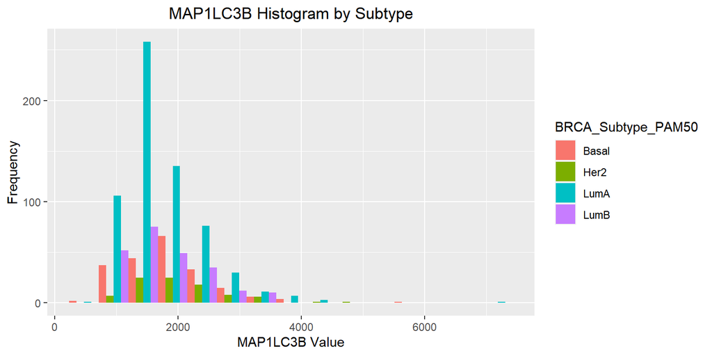

[output not shown]

```r
randgene5<-brca[, c("BRCA_Subtype_PAM50", "MAP1LC3B")]

ggplot(randgene5, aes(x = MAP1LC3B, fill = BRCA_Subtype_PAM50)) +
  geom_histogram(bins = 15, position = "dodge") +
  labs(title = "MAP1LC3B Histogram by Subtype", x = "MAP1LC3B Value", y = "Frequency") +
theme(plot.title = element_text(hjust = 0.5))
```

```r
brca <- brca[,-1]
dim(brca)

sel_cols <- which(colSums(abs(brca)) != 0)
new_brca <- brca[, sel_cols, with=F]

log_brca <- log2(as.matrix(new_brca+1e-10))

nzv <- nearZeroVar(log_brca)
log_brca <- log_brca[, -nzv]

dim(log_brca)
```

```
## [1]  1160 19947
## [1]  1160 18587
```

2. Apply kmeans on the transformed dataset with 4 centers and output the discrepancy table between the real sub-type `brca_subtype` and the cluster labels.

```r
kmean_brca <- kmeans(log_brca, centers = 4)
str(kmean_brca)
```

```
## List of 9
##  $ cluster     : int [1:1160] 3 3 2 3 3 3 3 2 3 3 ...
##  $ centers     : num [1:4, 1:18587] 6.11 7.31 7.28 6.42 14.85 ...
##   ..- attr(*, "dimnames")=List of 2
##   .. ..$ : chr [1:4] "1" "2" "3" "4"
##   .. ..$ : chr [1:18587] "A1BG" "A2M" "NAT1" "NAT2" ...
##  $ totss       : num 8.34e+08
##  $ withinss    : num [1:4] 7.51e+07 2.16e+08 3.29e+08 1.47e+08
##  $ tot.withinss: num 7.68e+08
##  $ betweenss   : num 66553999
##  $ size        : int [1:4] 133 278 543 206
##  $ iter        : int 4
##  $ ifault      : int 0
##  - attr(*, "class")= chr "kmeans"
```

```r
cluster <- as.factor(kmean_brca$cluster)
discrepancy_table <- table(brca_subtype, cluster)
discrepancy_table
```

```
##             cluster
## brca_subtype   1   2   3   4
##        Basal  17   3   1 187
##        Her2    9  23  42  17
##        LumA   85 147 396   0
##        LumB   22 105 104   2
```

3. Spectrum clustering: to scale or not to scale?
   1. Apply PCA on the centered and scaled dataset. How many PCs should we use and why? You are encouraged to use `irlba::irlba()`.

```r
center_sacle_log_brca<-scale(as.matrix(log_brca), center = T, scale = T)
pca_fit1 <-prcomp(center_sacle_log_brca)
summary(pca_fit1)$importance[,1:50]
```

```
##                           PC1     PC2     PC3     PC4     PC5     PC6     PC7
## Standard deviation     45.948 36.0118 35.6308 24.0886 23.3160 18.9934 18.1794
## Proportion of Variance  0.114  0.0698  0.0683  0.0312  0.0293  0.0194  0.0178
## Cumulative Proportion   0.114  0.1834  0.2517  0.2829  0.3121  0.3315  0.3493
##                            PC8     PC9    PC10     PC11     PC12     PC13
## Standard deviation     16.4701 14.5052 13.9364 13.26093 12.86785 12.07662
## Proportion of Variance  0.0146  0.0113  0.0104  0.00946  0.00891  0.00785
## Cumulative Proportion   0.3639  0.3752  0.3857  0.39514  0.40405  0.41190
##                            PC14     PC15     PC16     PC17     PC18    PC19
## Standard deviation     11.81444 11.00478 10.87899 10.45855 10.37345 9.98432
## Proportion of Variance  0.00751  0.00652  0.00637  0.00588  0.00579 0.00536
## Cumulative Proportion   0.41940  0.42592  0.43229  0.43817  0.44396 0.44933
##                           PC20    PC21    PC22   PC23    PC24    PC25    PC26
## Standard deviation     9.88443 9.63258 9.40588 9.2472 9.11637 8.93277 8.88580
## Proportion of Variance 0.00526 0.00499 0.00476 0.0046 0.00447 0.00429 0.00425
## Cumulative Proportion  0.45458 0.45957 0.46433 0.4689 0.47341 0.47770 0.48195
##                           PC27    PC28    PC29    PC30   PC31    PC32    PC33
## Standard deviation     8.70856 8.55171 8.44412 8.32013 8.2894 8.13055 8.01585
## Proportion of Variance 0.00408 0.00393 0.00384 0.00372 0.0037 0.00356 0.00346
## Cumulative Proportion  0.48603 0.48996 0.49380 0.49752 0.5012 0.50478 0.50823
##                           PC34    PC35    PC36    PC37    PC38    PC39    PC40
## Standard deviation     7.95976 7.90149 7.78845 7.62956 7.54286 7.52672 7.40871
## Proportion of Variance 0.00341 0.00336 0.00326 0.00313 0.00306 0.00305 0.00295
## Cumulative Proportion  0.51164 0.51500 0.51826 0.52140 0.52446 0.52750 0.53046
##                           PC41    PC42    PC43    PC44    PC45    PC46    PC47
## Standard deviation     7.35486 7.24217 7.20749 7.12331 7.07602 6.98526 6.96788
## Proportion of Variance 0.00291 0.00282 0.00279 0.00273 0.00269 0.00263 0.00261
## Cumulative Proportion  0.53337 0.53619 0.53898 0.54171 0.54441 0.54703 0.54965
##                           PC48   PC49    PC50
## Standard deviation     6.94236 6.8181 6.78557
## Proportion of Variance 0.00259 0.0025 0.00248
## Cumulative Proportion  0.55224 0.5547 0.55722
```

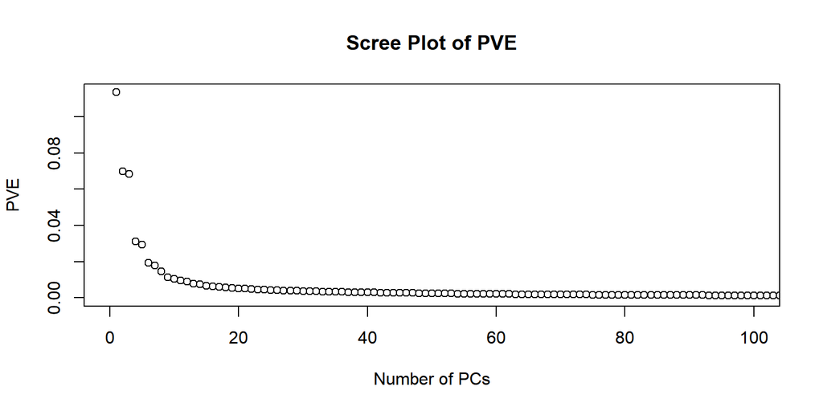

```r
plot(summary(pca_fit1)$importance[2, ],
ylab="PVE",
xlab="Number of PCs",
xlim=c(0,100),
main="Scree Plot of PVE")
```

We should use 8 principal components according to the elbow rules, because after 8 principal components PVE grows very slowly .

```
b) Plot PC1 vs PC2 of the centered and scaled data and PC1 vs PC2 of the centered but unscaled data side by side. Should we scale or not scale for clustering process? Why? (Hint: to put plots side by side, use `gridExtra::grid.arrange()` or `ggpubr::ggrrange()` or `egg::ggrrange()` for ggplots; use `fig.show="hold"` as chunk option for base plots)
```

```r
center_log_brca<-scale(as.matrix(log_brca), center=T, scale=F)
pca_fit2 <-prcomp(center_log_brca)
summary(pca_fit2)$importance[,1:50]
```

```
##                             PC1      PC2      PC3      PC4     PC5     PC6
## Standard deviation     202.1158 161.5752 129.1453 101.1324 96.9010 92.3639
## Proportion of Variance   0.0568   0.0363   0.0232   0.0142  0.0131  0.0118
## Cumulative Proportion    0.0568   0.0930   0.1162   0.1304  0.1435  0.1553
##                             PC7      PC8      PC9     PC10     PC11     PC12
## Standard deviation     80.77410 75.97130 73.99719 64.91974 62.83309 61.67422
## Proportion of Variance  0.00907  0.00802  0.00761  0.00586  0.00549  0.00528
## Cumulative Proportion   0.16438  0.17240  0.18001  0.18586  0.19135  0.19663
##                            PC13     PC14    PC15     PC16     PC17     PC18
## Standard deviation     59.50287 56.51087 54.2902 53.42965 50.98997 49.75279
## Proportion of Variance  0.00492  0.00444  0.0041  0.00397  0.00361  0.00344
## Cumulative Proportion   0.20155  0.20599  0.2101  0.21405  0.21766  0.22110
##                            PC19     PC20   PC21     PC22     PC23     PC24
## Standard deviation     48.48054 47.12730 46.475 45.97179 45.73422 44.60989
## Proportion of Variance  0.00327  0.00309  0.003  0.00294  0.00291  0.00276
## Cumulative Proportion   0.22437  0.22745  0.230  0.23339  0.23630  0.23906
##                            PC25     PC26     PC27     PC28     PC29     PC30
## Standard deviation     44.30007 43.43974 42.75269 42.07903 41.65722 41.20326
## Proportion of Variance  0.00273  0.00262  0.00254  0.00246  0.00241  0.00236
## Cumulative Proportion   0.24179  0.24441  0.24695  0.24941  0.25182  0.25418
##                            PC31     PC32     PC33     PC34     PC35     PC36
## Standard deviation     40.73873 40.26344 40.06433 39.96894 39.69904 39.51995
## Proportion of Variance  0.00231  0.00225  0.00223  0.00222  0.00219  0.00217
## Cumulative Proportion   0.25648  0.25874  0.26097  0.26319  0.26538  0.26755
##                            PC37     PC38     PC39     PC40     PC41   PC42
## Standard deviation     39.23025 39.19610 38.76419 38.37802 38.19777 37.918
## Proportion of Variance  0.00214  0.00213  0.00209  0.00205  0.00203  0.002
## Cumulative Proportion   0.26968  0.27182  0.27391  0.27595  0.27798  0.280
##                            PC43     PC44     PC45     PC46     PC47    PC48
## Standard deviation     37.86963 37.66253 37.61954 37.31803 37.23415 37.0045
## Proportion of Variance  0.00199  0.00197  0.00197  0.00193  0.00193  0.0019
## Cumulative Proportion   0.28197  0.28394  0.28591  0.28784  0.28977  0.2917
##                            PC49     PC50
## Standard deviation     36.84626 36.62321
## Proportion of Variance  0.00189  0.00186
## Cumulative Proportion   0.29356  0.29542
```

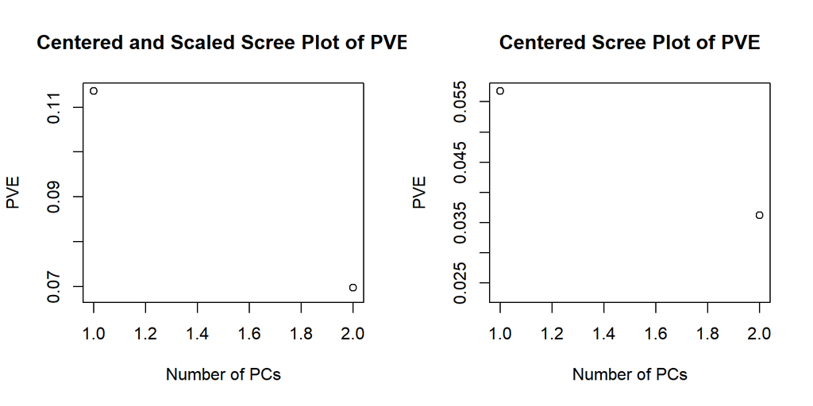

```r
par(mfrow=c(1,2))

p1<-plot(summary(pca_fit1)$importance[2, 1:3],
ylab="PVE",
xlab="Number of PCs",
xlim=c(1,2),
main="Centered and Scaled Scree Plot of PVE")

p2<-plot(summary(pca_fit2)$importance[2, 1:3],
ylab="PVE",
xlab="Number of PCs",
xlim=c(1,2),
main="Centered Scree Plot of PVE")
```

```r
par(mfrow=c(1,1))
```

From these two plots above, we can see that both PC1 and PC2 in the centered and scaled PCA explains more PVE than PC1 and PC2 in the centered PCA respectively, so we should scale in the clustering process.

4. Spectrum clustering: center but do not scale the data
   1. Use the first 4 PCs of the centered and unscaled data and apply kmeans. Find a reasonable number of clusters using within sum of squared with the elbow rule.

```r
fourpc<-pca_fit2$x[, 1:4]
```

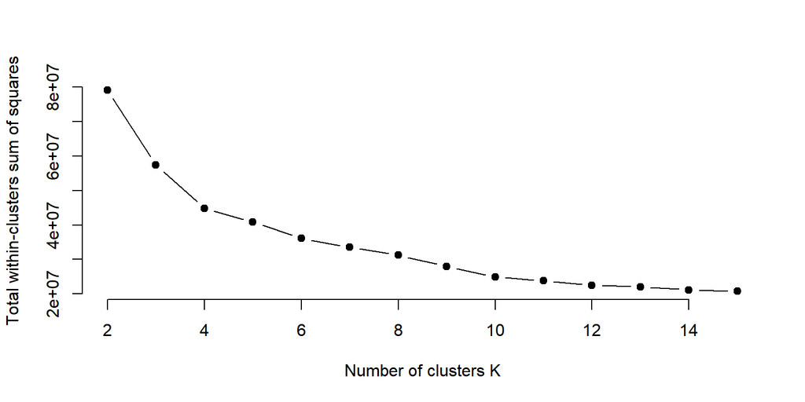

```r
set.seed(0)

wss <- function(df, k) {
kmeans(df, k, nstart = 10)$tot.withinss
}

k.values <- 2:15
wss_values <- sapply(k.values, function(k) kmeans(fourpc, centers = k)$tot.withinss)

plot(k.values, wss_values,
type="b", pch = 19, frame = FALSE,
xlab="Number of clusters K",
ylab="Total within-clusters sum of squares")
```

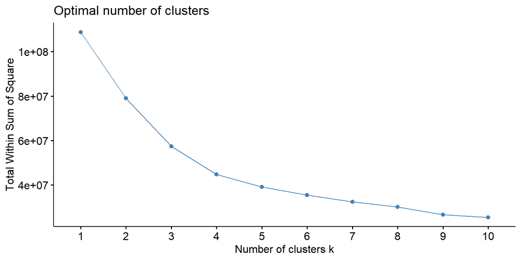

```r
library(factoextra)
fviz_nbclust(fourpc, kmeans, method = "wss")
```

According to the elbow method, we decide to use k=4 to have four clusters.

```
b) Choose an optimal cluster number and apply kmeans. Compare the real sub-type and the clustering label as follows: Plot scatter plot of PC1 vs PC2. Use point color to indicate the true cancer type and point shape to indicate the clustering label. Plot the kmeans centroids with black dots. Summarize how good is clustering results compared to the real sub-type.
```

Just as above, we choose k=4.

```r
kmean_brca2 <- kmeans(fourpc, centers = 4)
str(kmean_brca2)
kmean_brca2$center
```

```
## List of 9
##  $ cluster     : int [1:1160] 2 2 3 2 2 2 2 3 2 2 ...
##  $ centers     : num [1:4, 1:4] 56.6 48.5 -251.6 274.9 295.7 ...
##   ..- attr(*, "dimnames")=List of 2
##   .. ..$ : chr [1:4] "1" "2" "3" "4"
##   .. ..$ : chr [1:4] "PC1" "PC2" "PC3" "PC4"
##  $ totss       : num 1.09e+08
##  $ withinss    : num [1:4] 9494611 14676441 12900480 7665179
##  $ tot.withinss: num 44736710
##  $ betweenss   : num 64051190
##  $ size        : int [1:4] 217 504 299 140
##  $ iter        : int 3
##  $ ifault      : int 0
##  - attr(*, "class")= chr "kmeans"
##      PC1   PC2     PC3    PC4
## 1   56.6 295.7    2.79 -3.100
## 2   48.5 -74.6   71.33  3.869
## 3 -251.6 -50.7  -21.63 -4.473
## 4  274.9 -81.4 -214.91  0.431
```

```r
cluster <- as.factor(kmean_brca2$cluster)
data<-data.frame(fourpc[,1:2])
data2<-data.frame(data, type = brca_subtype, label =  cluster)
kmean_brca2$centers[,1:2]
```

```
##      PC1   PC2
## 1   56.6 295.7
## 2   48.5 -74.6
## 3 -251.6 -50.7
## 4  274.9 -81.4
```

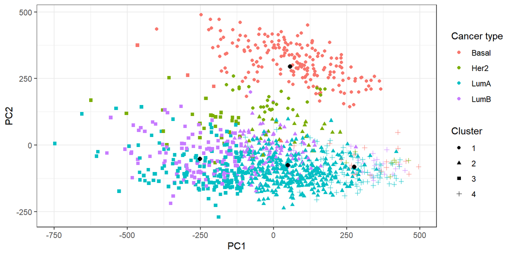

```r
p<-data.table(x = data2$PC1,
                y = data2$PC2,
                col = as.factor(data2$type),
                cl = data2$label,
                pc1=kmean_brca2$centers[,1],
                pc2=kmean_brca2$centers[,2]) %>%
  ggplot() +
  geom_point(aes(x = x, y = y, col = col, shape = cl)) +
  geom_point(aes(x = pc1, y = pc2), size = 2, fill = "black") +
  theme_bw() +
  labs(color = "Cancer type", shape = "Cluster") +
  xlab("PC1") +
  ylab("PC2")

p
```

Cluster 1 centers at the center of Basal; cluster 2 centers at around the center of LumA; cluster 3 centers at around the center of LumB; cluster 4 centers deviates quite a bit from the center of Her2. The clustering is good for 3 type of cancers, but not for Her2.

```
c) Compare the clustering result from applying kmeans to the original data and the clustering result from applying kmeans to 4 PCs. Does PCA help in kmeans clustering? What might be the reasons if PCA helps?
```

```r
discrepancy_table
```

```
##             cluster
## brca_subtype   1   2   3   4
##        Basal  17   3   1 187
##        Her2    9  23  42  17
##        LumA   85 147 396   0
##        LumB   22 105 104   2
```

Looking at the above table from applying kmeans to the original data, we can see that only cluster 4 clearly points to Basal. Cluster 1, 2, 3 all have the highest number of points at LumA. After applying the PCA, the clustering does a better job differentiating cancer types. Original data has a high dimension. PCA helps reduce dimensionality, and having a smaller dimension is better for clustering. Also, since the principal components capture the most important features of the data, using PCA can help reduce the noise in the data.

```
d) Now we have an x patient with breast cancer but with unknown sub-type. We have this patient's mRNA sequencing data. Project this x patient to the space of PC1 and PC2. (Hint: remember we remove some gene with no counts or no variablity, take log and centered) Plot this patient in the plot in iv) with a black dot. Calculate the Euclidean distance between this patient and each of centroid of the cluster. Can you tell which sub-type this patient might have?
```

```r
x_patient <- fread("data/brca_x_patient.csv")
```

```r
dim(x_patient)

loading1<-pca_fit2$rotation[,1]
loading2<-pca_fit2$rotation[,2]
loading1<-data.frame(loading1)
dim(loading1)

common_cols <- intersect(colnames(x_patient), rownames(loading1))
x_patient <- x_patient[, ..common_cols]
```

```
## [1]     1 19947
## [1] 18587     1
```

```r
log_x_patient <- log2(as.matrix(x_patient+1e-10))
center_log_x_patient<-log_x_patient-colMeans(log_brca)
```

```r
pc1score<-as.matrix(center_log_x_patient)%*%as.matrix(loading1)
pc2score<-as.matrix(center_log_x_patient)%*%as.matrix(loading2)
pc1score
pc2score
```

```
##      loading1
## [1,]    -3.75
##      [,1]
## [1,]  417
```

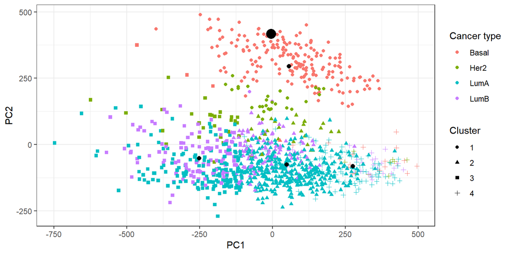

```r
data.table(x = data2$PC1,
                y = data2$PC2,
                col = as.factor(data2$type),
                cl = data2$label,
                pc1=kmean_brca2$centers[,1],
                pc2=kmean_brca2$centers[,2],
                pc1score=pc1score,
                pc2score=pc2score )%>%
  ggplot() +
  geom_point(aes(x = x, y = y, col = col, shape = cl)) +
  geom_point(aes(x = pc1, y = pc2), size = 2) +
  geom_point(aes(x = pc1score, y = pc2score), size = 5) +
  theme_bw() +
  labs(color = "Cancer type", shape = "Cluster") +
  xlab("PC1") +
  ylab("PC2")
```

The big black dot is the patient. The small black dots are cluster centers.

```r
#library(stats)
patient <- c(pc1score, pc2score)
centroids <- rbind(c(kmean_brca2$centers[,1][1], kmean_brca2$centers[,2][1]), c(kmean_brca2$centers[,1][2], kmean_brca2$centers[,2][2]), c(kmean_brca2$centers[,1][3], kmean_brca2$centers[,2][3]), c(kmean_brca2$centers[,1][4], kmean_brca2$centers[,2][4]))
distances <- apply(centroids, 1, function(centroid) {
  dist(rbind(patient, centroid))
})
print(distances)
```

```
## [1] 135 494 529 571
```

The distance between the patient and cluster centers is the smallest when it is between the patient and cluster 1. So the patient might have Basal.

# 3 Case study 3: Auto data set

This question utilizes the `Auto` dataset from ISLR. The original dataset contains 408 observations about cars. It is similar to the CARS dataset that we use in our lectures. To get the data, first install the package ISLR. The `Auto` dataset should be loaded automatically. We’ll use this dataset to practice the methods learn so far. Original data source is here: https://archive.ics.uci.edu/ml/datasets/auto+mpg

Get familiar with this dataset first. Tip: you can use the command `?ISLR::Auto` to view a description of the dataset.

## 3.1 EDA

Explore the data, with particular focus on pairwise plots and summary statistics. Briefly summarize your findings and any peculiarities in the data.

```r
head(Auto)
```

```
##   mpg cylinders displacement horsepower weight acceleration year origin
## 1  18         8          307        130   3504         12.0   70      1
## 2  15         8          350        165   3693         11.5   70      1
## 3  18         8          318        150   3436         11.0   70      1
## 4  16         8          304        150   3433         12.0   70      1
## 5  17         8          302        140   3449         10.5   70      1
## 6  15         8          429        198   4341         10.0   70      1
##                        name
## 1 chevrolet chevelle malibu
## 2         buick skylark 320
## 3        plymouth satellite
## 4             amc rebel sst
## 5               ford torino
## 6          ford galaxie 500
```

```r
names(Auto)
```

```
## [1] "mpg"          "cylinders"    "displacement" "horsepower"   "weight"
## [6] "acceleration" "year"         "origin"       "name"
```

```r
summary(Auto)
```

```
##       mpg         cylinders     displacement   horsepower        weight
##  Min.   : 9.0   Min.   :3.00   Min.   : 68   Min.   : 46.0   Min.   :1613
##  1st Qu.:17.0   1st Qu.:4.00   1st Qu.:105   1st Qu.: 75.0   1st Qu.:2225
##  Median :22.8   Median :4.00   Median :151   Median : 93.5   Median :2804
##  Mean   :23.4   Mean   :5.47   Mean   :194   Mean   :104.5   Mean   :2978
##  3rd Qu.:29.0   3rd Qu.:8.00   3rd Qu.:276   3rd Qu.:126.0   3rd Qu.:3615
##  Max.   :46.6   Max.   :8.00   Max.   :455   Max.   :230.0   Max.   :5140
##
##   acceleration       year        origin                     name
##  Min.   : 8.0   Min.   :70   Min.   :1.00   amc matador       :  5
##  1st Qu.:13.8   1st Qu.:73   1st Qu.:1.00   ford pinto        :  5
##  Median :15.5   Median :76   Median :1.00   toyota corolla    :  5
##  Mean   :15.5   Mean   :76   Mean   :1.58   amc gremlin       :  4
##  3rd Qu.:17.0   3rd Qu.:79   3rd Qu.:2.00   amc hornet        :  4
##  Max.   :24.8   Max.   :82   Max.   :3.00   chevrolet chevette:  4
##                                             (Other)           :365
```

We have in total 392 data in Auto and 9 variables. From the data description and the above summary, we have continuous columns including mpg, displacement, horsepower, weight, acceleration and multi-valued discrete variables including cylinders, year, origin, and a string column of name.

```r
colSums(is.na(Auto))
```

```
##          mpg    cylinders displacement   horsepower       weight acceleration
##            0            0            0            0            0            0
##         year       origin         name
##            0            0            0
```

There are no Null values in the Auto dataset. We then visualize continuous and discrete variables distribution to learn more about the dataset.

```r
table(Auto$cylinders)
```

```
##
##   3   4   5   6   8
##   4 199   3  83 103
```

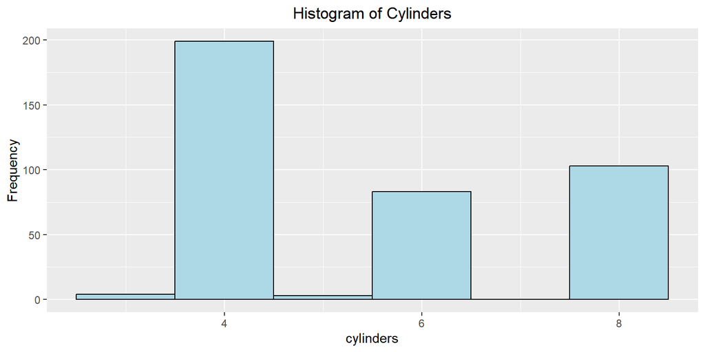

```r
ggplot(Auto, aes(x=cylinders)) + geom_histogram(bins=6, fill="lightblue", color="black") +
  xlab("cylinders") + ylab("Frequency") + ggtitle("Histogram of Cylinders")  +
theme(plot.title = element_text(hjust = 0.5))
```

There are seldom car with cylinders number 3 and 5 and no 7 cylinders. Majority of cars have 4 cylinders while there are amount of cars have 6 or 8 cylinders.

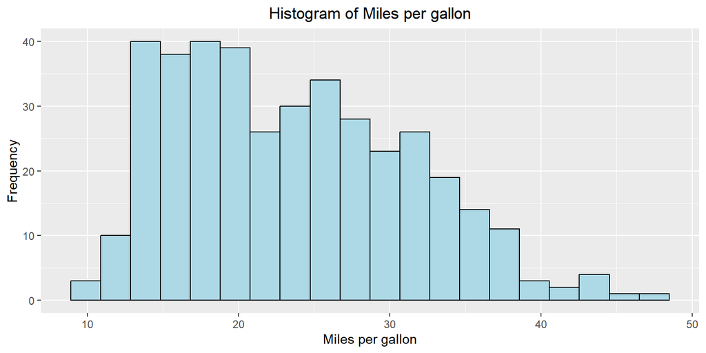

```r
ggplot(Auto, aes(x=mpg)) + geom_histogram(bins=20, fill="lightblue", color="black") +
  xlab("Miles per gallon") + ylab("Frequency") + ggtitle("Histogram of Miles per gallon")  +
  theme(plot.title = element_text(hjust = 0.5))
```

```r
length(unique(Auto$name))
```

```
## [1] 301
```

We have 392 data points in total but with 301 names. Most of names only have one data point. This column will not be useful in our case.

```r
table(Auto$year)
```

```
##
## 70 71 72 73 74 75 76 77 78 79 80 81 82
## 29 27 28 40 26 30 34 28 36 29 27 28 30
```

```r
length(unique(Auto$year))
```

```
## [1] 13
```

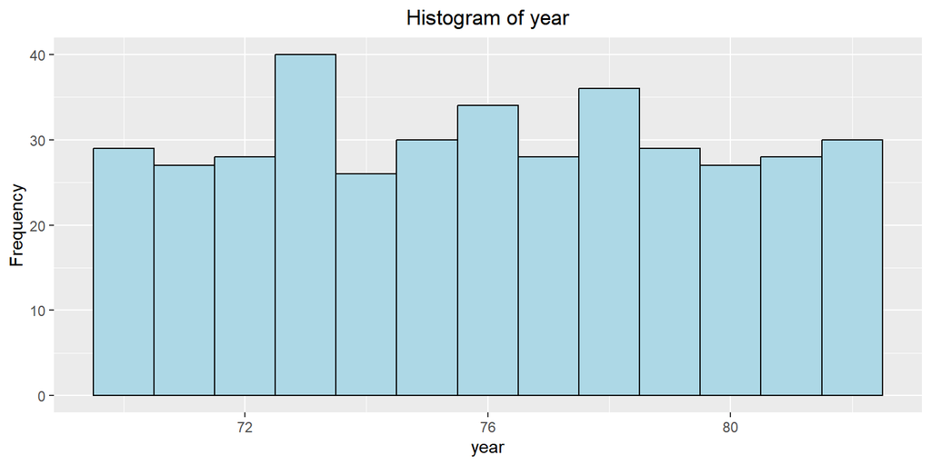

```r
ggplot(Auto, aes(x=year)) + geom_histogram(bins=13, fill="lightblue", color="black") +
  xlab("year") + ylab("Frequency") + ggtitle("Histogram of year")  +
theme(plot.title = element_text(hjust = 0.5))
```

The samples evenly scattered across years.

```r
table(Auto$origin)
```

```
##
##   1   2   3
## 245  68  79
```

```r
length(unique(Auto$origin))
```

```
## [1] 3
```

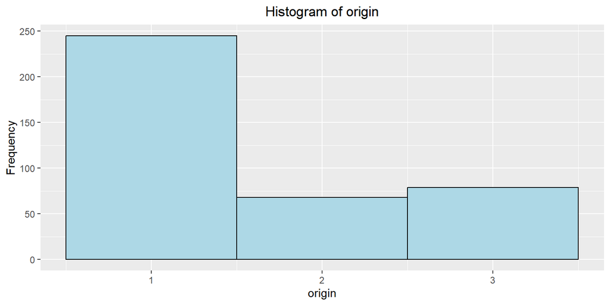

```r
ggplot(Auto, aes(x=origin)) + geom_histogram(bins=3, fill="lightblue", color="black") +
  xlab("origin") + ylab("Frequency") + ggtitle("Histogram of origin")  +
theme(plot.title = element_text(hjust = 0.5))
```

Most samples have origin 1.

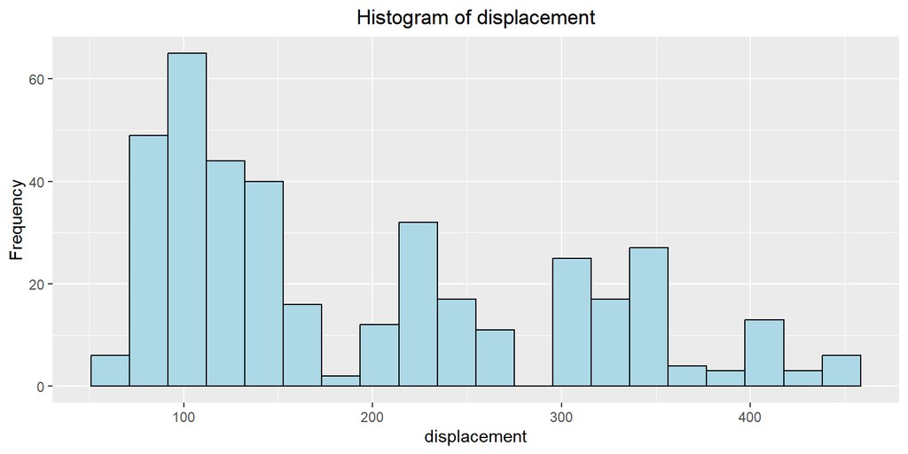

```r
ggplot(Auto, aes(x=displacement)) + geom_histogram(bins=20, fill="lightblue", color="black") +
  xlab("displacement") + ylab("Frequency") + ggtitle("Histogram of displacement")  +
theme(plot.title = element_text(hjust = 0.5))
```

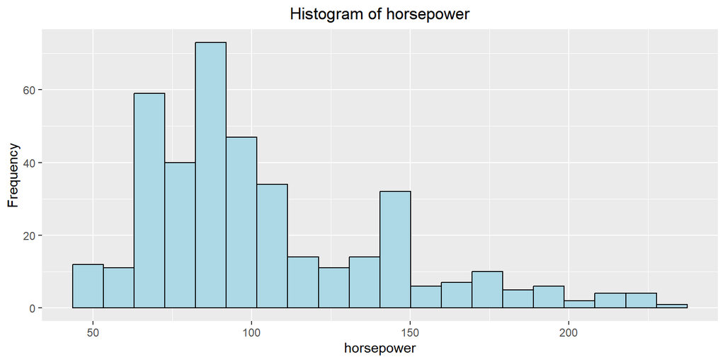

```r
ggplot(Auto, aes(x=horsepower)) + geom_histogram(bins=20, fill="lightblue", color="black") +
  xlab("horsepower") + ylab("Frequency") + ggtitle("Histogram of horsepower")  +
theme(plot.title = element_text(hjust = 0.5))
```

The horsepower are focused from 70 to 100.

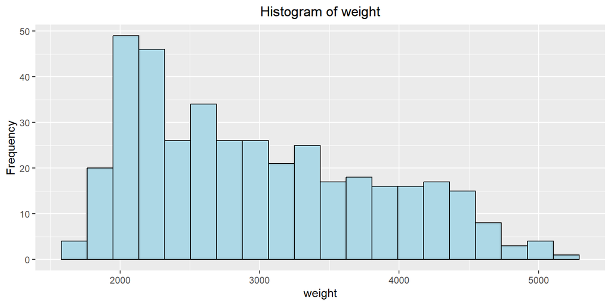

```r
ggplot(Auto, aes(x=weight)) + geom_histogram(bins=20, fill="lightblue", color="black") +
  xlab("weight") + ylab("Frequency") + ggtitle("Histogram of weight")  +
theme(plot.title = element_text(hjust = 0.5))
```

The weights are roughly evenly distributed from 2000 to 4000 but more samples have weights around 2000.

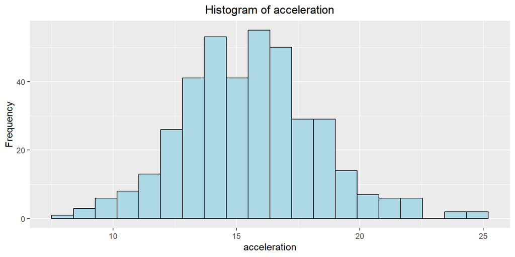

```r
ggplot(Auto, aes(x=acceleration)) + geom_histogram(bins=20, fill="lightblue", color="black") +
  xlab("acceleration") + ylab("Frequency") + ggtitle("Histogram of acceleration")  +
theme(plot.title = element_text(hjust = 0.5))
```

The distribution satisfies normal distribution that most samples have acceleration ranging from 14 to 19.

We then do pair analysis by removing the factor variable, i.e. name.

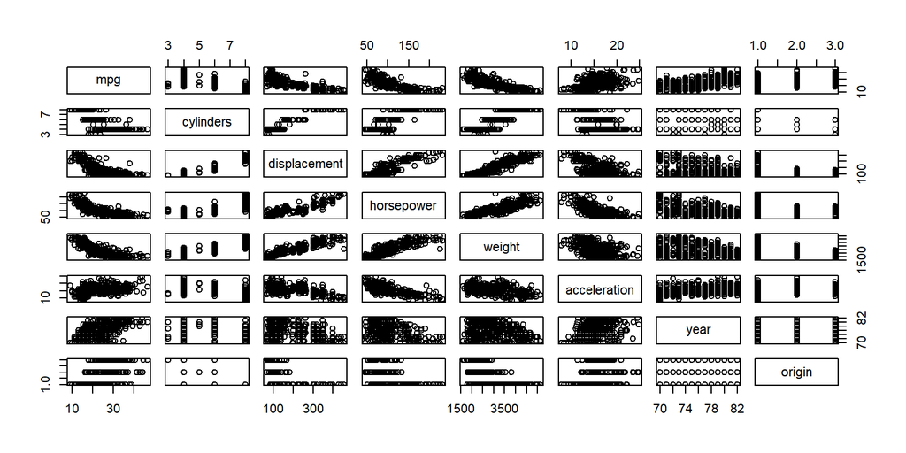

```r
pairs(Auto[, -c(9)])
```

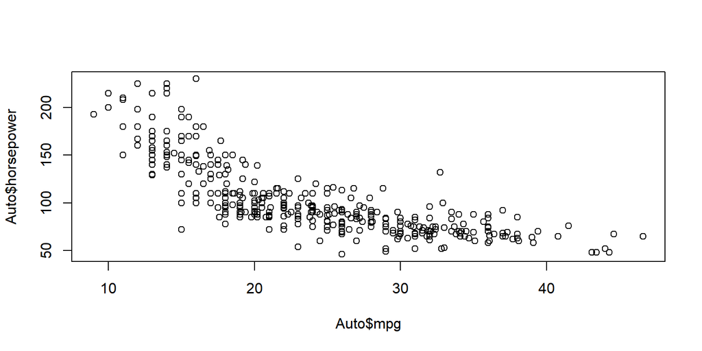

```r
plot(Auto$mpg, Auto$horsepower)
```

Above is the enlarged scatter plot showing mpg vs horsepower.